# Блокнотная среда Jupyter Notebook

## Код HTML в тексте с разметкой

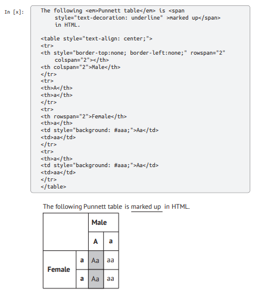

### Списки

Маркированные (ненумерованные) списки создаются с использованием любых маркеров *, + или – , а вложенные подсписки просто смещаются соответствующим образом.

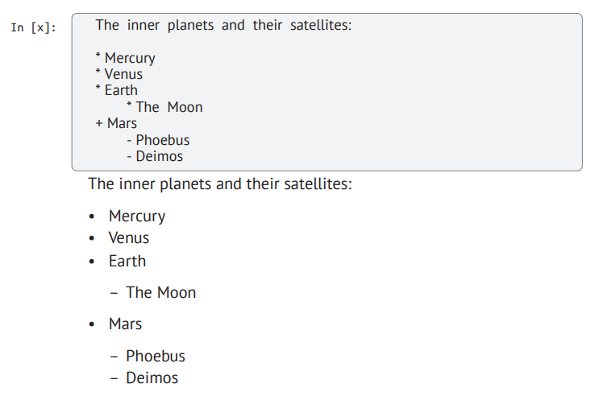

Упорядоченные, или нумерованные, списки создаются с применением номеров (чисел) с точкой и пробелом перед каждым пунктом списка:

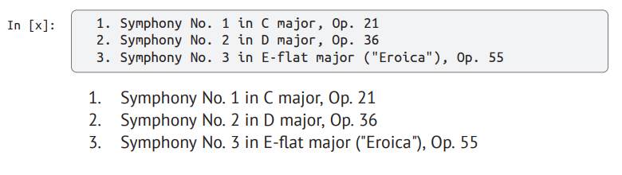

### Ссылки

Существуют три способа создания ссылок в тексте с разметкой:

- ссылки в строке (inline links) – URL записывается в круглых скобках после текста в квадратных скобках, который должен быть преобразован в ссылку. Например:

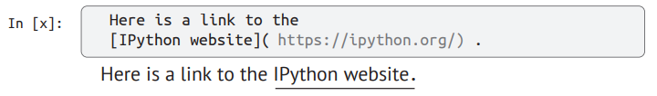

- гиперссылки (reference links) помечают текст, который должен быть преобразован в ссылку, помещая имя ссылки (содержащее буквы, числа и пробелы) в квадратных скобках. Предполагается, что имя определяется с использованием следующего синтаксиса [имя]: url где-либо в документе, как показано в приведенном ниже примере ячейкитекста с разметкой:

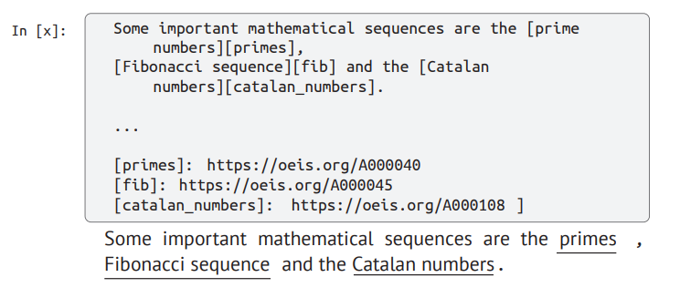

- автоматические ссылки (automatic links) – для них текст, по которому можно щелкнуть,представляет собой URL.Такие ссылки создаются простым размещением URL в угловых скобках:

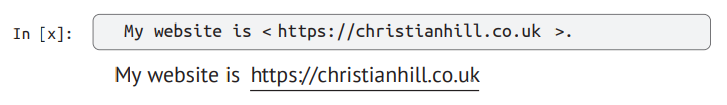

Если ссылкой является файл в локальной системе,то в качестве URL задается путевое имя относительно каталога текущего блокнота с префиксом files/.

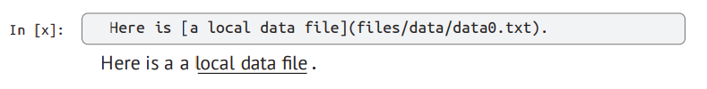

Обратите внимание: при щелчке по любой ссылке открывается новая вкладка в браузере.

### Математика

Математические формулы могут записываться на языке LaTeX и в дальнейшем отображаются с использованием библиотеки JavaScript MathJax. Формулы в строке текста выделяются одиночными символами доллара, а отдельно выводимые формулы выделяются двойными символами доллара:

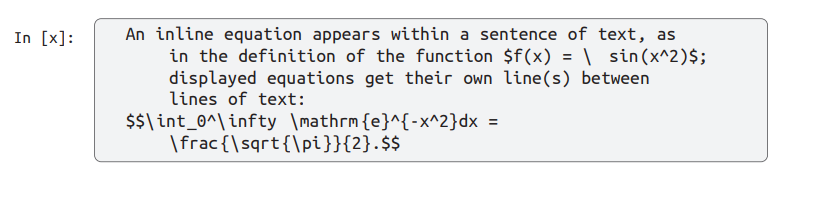

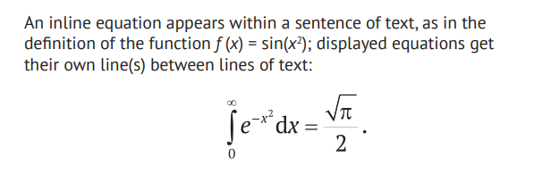

### Изображения и видеофрагменты

Ссылки на файлы изображений работают точно так же, как обычные ссылки (и могут быть ссылками в строке текста или гиперссылками), но им предшествует восклицательный знак !. Текст в квадратных скобках между восклицательным знаком и ссылкой действует как текст, заменяющий изображение. Например:

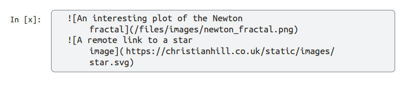

[video not shown]

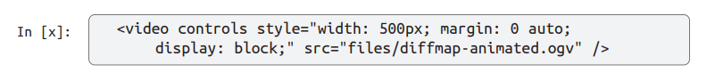

Данные, формирующие изображения, видео и другой локально позиционируемый контент, не включаются непосредственно в документ блокнота: эти файлы обязательно должны включаться в дистрибутивный комплект блокнота при распространении.

### Преобразование документа блокнота в другие форматы

Инструментальное средство nbconverter устанавливается вместе с Jupyter Notebook для преобразования блокнотов из собственного формата .ipynb62 в один из нескольких альтернативных форматов. Инструмент преобразования запускается из (системной) командной строки:

```
jupyter nbconvert --to <format> <notebook.ipynb>
```

где notebook.ipynb –имя файла блокнота Jupyter Notebook, который необходимо преобразовать, а format – требуемый формат вывода. По умолчанию (если параметр format не задан) результатом становится статический HTML-файл, как описано в следующем разделе

### Преобразование в формат HTML

```
jupyter nbconvert <notebook.ipynb>
```

### Преобразование в формат LaTeX

Для экспорта блокнота в формате документа LaTeX применяется команда

```
jupyter nbconvert --to latex <notebook.ipynb>
```

Для автоматической генерации PDF-файла с помощью утилиты pdflatex, применяемой к преобразованному файлу notebook.tex, в приведенную выше команду добавляется ключ --post pdf.

### Преобразование в формат Markdown

Команда

```
jupyter nbconvert --to markdown <notebook.ipynb>
```

выполняет преобразование всего блокнота в целом в формат markdown (https:// daringfireball.net/projects/markdown/): ячейки, уже содержащие текст в формате markdown, не изменяются, а ячейки кода размещаются в блоках с тройным обратным апострофом (```).

### Преобразование в код Python

Команда

```
jupyter nbconvert --to python <notebook.ipynb>
```

выполняет преобразование файла notebook.ipynb в выполняемый скрипт Python. Если какая-либо из ячеек кода этого блокнота содержит магические функции IPython, то сгенерированный скрипт может выполняться только в сеансе IPython. Ячейки в формате markdown и прочие текстовые ячейки будут преобразованы в комментарии в сгенерированном коде скрипта Python.

### JupyterLab

Во время написания этой книги проект Project Jupyter тестировал интерактивную среду разработки (IDE) на основе браузера JupyterLab, которая расширяет функциональность виртуальной блокнотной среды Jupyter Notebook и обеспечивает совместную работу нескольких пользователей, поддержку метода «перетащи и брось» (drag-and-drop) для ячеек блокнота, доступ к терминалу (консоли) на основе браузера, автоматическое завершение ключевых слов и имен объектов, а также динамический предварительный просмотр текста с разметкой markdown. Поддерживается возможность установки специализированных сторонних виджетов, позволяющих загружать и исследовать данные в различных форматах прямо в браузере, а также интеграция с широко известными онлайновыми сервисами, такими как GitHub, Dropbox и Google Drive. Будет обеспечена полная обратная совместимость с существующими блокнотами Jupyter Notebook. Более подробную информацию о JupyterLab можно найти на веб-сайте проекта Project Jupyter https://jupyter.org/.